# BDA Coursework 1 - Geoff Moran

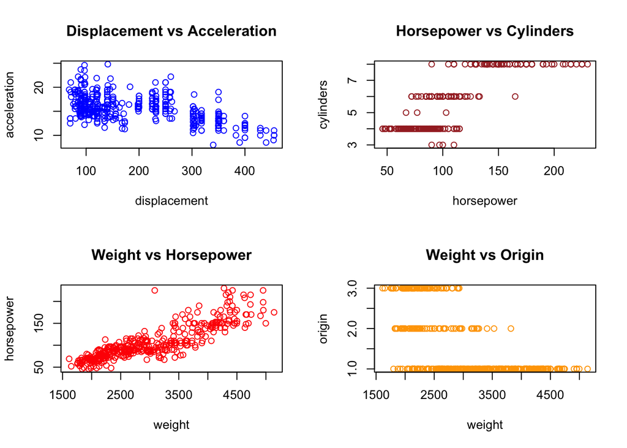

```r
attach(Auto)
par(mfrow=c(2,2))
plot(displacement, acceleration, col='blue', main="Displacement vs Acceleration")
plot(horsepower, cylinders, col='brown', main="Horsepower vs Cylinders")
plot(weight, horsepower, col='red', main="Weight vs Horsepower")
plot(weight, origin, col='orange', main="Weight vs Origin")
```

**Displacement vs Acceleration**: it is clear that there is a negative relationship between displacement and acceleration. As displacement increases, acceleration generally decreases.  
**Horsepower vs Cyclinders**: there is a clear relationship showing that a higher number of cyclinders (8 for example) yields higher horsepower.  
**Weight vs Horsepower**: the relationship between weight and horsepower is non-linear, however the relationship is clearly positive. As weight increases, horsepower increases.  
**Weight vs Origin**: we can see that the maximum weight of American automobiles (1.0) far exceeds the weight of European (2.0) or Japanese (3.0) automobiles Japanese automobiles are generally lighter, with European automobiles generally sitting somewhere in between American and Japanese in terms of weight.

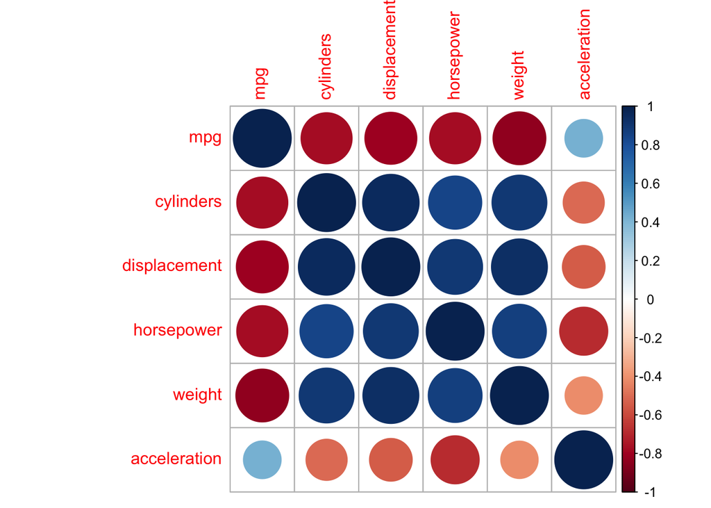

```r
correlations = cor(Auto[,-(7:9)])
corrplot(correlations, method="circle")
```

In this correlation plot blue represents positive correlation and red represents negative correlation. The larger the dot the larger the correlation. We can see that the diagonal are perfectly positively correlated because it shows the correlation of each attribute with itself.

**(f)**

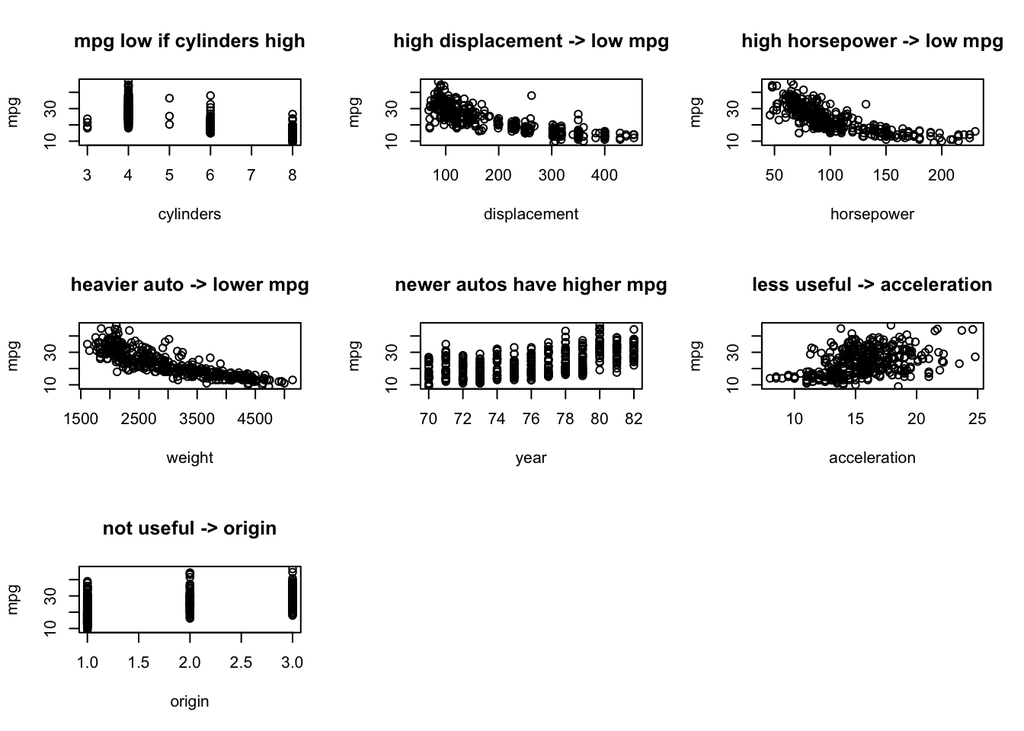

```r
par(mfrow=c(3,3))
plot(cylinders, mpg, main="mpg low if cylinders high")
plot(displacement, mpg, main="high displacement -> low mpg")
plot(horsepower, mpg, main="high horsepower -> low mpg")
plot(weight, mpg, main="heavier auto -> lower mpg")
plot(year, mpg, main="newer autos have higher mpg")
plot(acceleration, mpg, main="less useful -> acceleration")
plot(origin, mpg, main="not useful -> origin")
```

### Question 4. Linear regression

**(a)**

```r
model_1 = lm(mpg ~ horsepower, data=Auto)
summary(model_1)
```

```
##
## Call:
## lm(formula = mpg ~ horsepower, data = Auto)
##
## Residuals:
##      Min       1Q   Median       3Q      Max
## -13.5710  -3.2592  -0.3435   2.7630  16.9240
##
## Coefficients:
##              Estimate Std. Error t value Pr(>|t|)
## (Intercept) 39.935861   0.717499   55.66   <2e-16 ***
## horsepower  -0.157845   0.006446  -24.49   <2e-16 ***
## ---
## Signif. codes:  0 '***' 0.001 '**' 0.01 '*' 0.05 '.' 0.1 ' ' 1
##
## Residual standard error: 4.906 on 390 degrees of freedom
## Multiple R-squared:  0.6059, Adjusted R-squared:  0.6049
## F-statistic: 599.7 on 1 and 390 DF,  p-value: < 2.2e-16
```

**(i)** Yes there is a relationship between mpg and horsepower. The p-value is extremely small: <2e-16. We can therefore reject a null hypothesis (generally we could reject a p-value below 0.05 if testing with 95% confidence). Our null hypothesis states that the slope is 0, i.e. that there’s no relationship between mpg and horsepower. Now that it’s rejected we can say that there is a relationship.

**(ii)** The R2 value is nearly 0.6059 which tells us that in this regression model nearly 61% of the variance of mpg is explained by horsepower. This shows a relatively strong relationship, 100% being the strongest possible relationship and 0% being no relationship at all.

**(iii)** The relationship is negative. The estimate -0.157845 tells us that for every 1 unit increase in x (horsepower), there is an expected change of -0.157845 in y (mpg). This tells us that the relationship is negative.

As a side note, the F-statistic is very high and so leads us to again reject the null hypothesis; this again confirms that our results are statistically significant.

**(iv)**

```r
predict(model_1, data.frame(horsepower=89), interval ="confidence", level = 0.99)
```

```
##        fit      lwr      upr
## 1 25.88768 25.19633 26.57903
```

```r
predict(model_1, data.frame(horsepower=89), interval="predict", level = 0.99)
```

```
##        fit      lwr      upr
## 1 25.88768 13.17035 38.60501
```

The predicted mpg associated with a horsepower of 89 is 25.88768. The confidence interval is 25.19633 to 26.57903, meaning the range in which the true population parameter lies is small. The prediction interval is 13.1705 to 38.60501, which is a wider range than that of the confidence interval (which is expected).

**(b) and (c)**

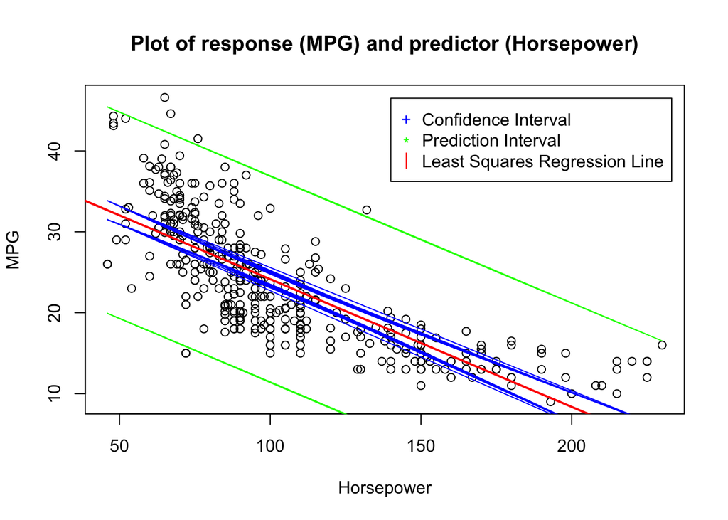

```r
par(mfrow=c(1,1))
plot(Auto$horsepower, Auto$mpg, xlab="Horsepower", ylab="MPG", main="Plot of response (MPG) and predictor (Horsepower)")
abline(model_1,lwd=2, col="Red")

p_conf = predict(model_1, data.frame(Auto$horsepower), interval="confidence", level=0.99)
p_pred = predict(model_1, data.frame(Auto$horsepower), interval="prediction", level=0.99)
lines(Auto$horsepower, p_conf[,"lwr"], col="blue", type="l", pch="+")
lines(Auto$horsepower, p_conf[,"upr"], col="blue", type="l", pch="+")
lines(Auto$horsepower, p_pred[,"upr"], col="green", type="l", pch="*")
lines(Auto$horsepower, p_pred[,"lwr"], col="green", type="l", pch="*")

legend(140,46.5,
       pch=c("+","*", "|"),
       col=c("blue","green", "red"),
       legend = c("Confidence Interval","Prediction Interval", "Least Squares Regression Line"))
```

### Question 5. Logistic regression

**(a)**

```r
training_data = read.delim("/Users/Geoff/Documents/Data Science MSc/Semester 1 October 2019/Big Data Analytics Using R (BDA)/Coursework/Training_set for Q5.txt", header = TRUE, sep = ",", dec = ".")
testing_data = read.delim("/Users/Geoff/Documents/Data Science MSc/Semester 1 October 2019/Big Data Analytics Using R (BDA)/Coursework/Testing_set for Q5.txt", header = TRUE, sep = ",", dec = ".")

train_subset = subset(training_data, select = c(Temperature, Humidity, Light, CO2))
summary(train_subset)
```

```
##   Temperature       Humidity         Light            CO2
##  Min.   :20.10   Min.   :18.96   Min.   :  0.0   Min.   : 426.0
##  1st Qu.:20.89   1st Qu.:21.82   1st Qu.:  0.0   1st Qu.: 448.0
##  Median :21.20   Median :25.00   Median :  0.0   Median : 485.5
##  Mean   :21.42   Mean   :24.22   Mean   :144.7   Mean   : 634.6
##  3rd Qu.:22.10   3rd Qu.:26.29   3rd Qu.:433.0   3rd Qu.: 845.8
##  Max.   :23.18   Max.   :28.50   Max.   :744.0   Max.   :1139.0
```

```r
cor(train_subset)
```

```
##             Temperature  Humidity     Light       CO2
## Temperature   1.0000000 0.7951377 0.6870315 0.8265514
## Humidity      0.7951377 1.0000000 0.4988627 0.5883773
## Light         0.6870315 0.4988627 1.0000000 0.8890452
## CO2           0.8265514 0.5883773 0.8890452 1.0000000
```

**(b)**

```r
training_data$Occupancy = as.factor(training_data$Occupancy)
testing_data$Occupancy = as.factor(testing_data$Occupancy)

glm.fit <- glm(Occupancy ~ Temperature, training_data, family='binomial')
glm.probs <- predict(glm.fit, testing_data, type='response')
glm.pred = rep("0", length(glm.probs))
glm.pred[glm.probs >.5]="1"
tab1 = table(Predicted = glm.pred, Actual = testing_data$Occupancy)
tab1
```

```
##          Actual
## Predicted   0   1
##         0 182  39
##         1  58  21
```

```r
print(paste("The predictive accuracy of this trained logistic regression model is",
            (tab1[1,1]+tab1[2,2])/sum(tab1)))
```

```
## [1] "The predictive accuracy of this trained logistic regression model is 0.676666666666667"
```

**(c)**

```r
glm.fit.humidity <- glm(Occupancy ~ Humidity, training_data, family='binomial')
glm.probs.humidity <- predict(glm.fit.humidity, testing_data, type='response')
glm.pred.humidity = rep("0", length(glm.probs.humidity))
glm.pred.humidity[glm.probs.humidity >.5]="1"
tab2 = table(Predicted = glm.pred.humidity, Actual = testing_data$Occupancy)
tab2
```

```
##          Actual
## Predicted   0   1
##         0 133  22
##         1 107  38
```

```r
print(paste("The predictive accuracy of this trained logistic regression model is",
            (tab2[1,1]+tab2[2,2])/sum(tab2)))
```

```
## [1] "The predictive accuracy of this trained logistic regression model is 0.57"
```

**(d)**

```r
glm.fit.all <- glm(Occupancy ~ Temperature + Humidity + Light + CO2 + HumidityRatio, training_data, family='binomial')
glm.probs.all = predict(glm.fit.all, testing_data, type = 'response')
glm.pred.all = rep("0", length(glm.probs.all))
glm.pred.all[glm.probs.all > .5] = "1"
tab3 = table(Predicted = glm.pred.all, Actual = testing_data$Occupancy)
print(paste("The predictive accuracy of this trained logistic regression model is",
            (tab3[1,1]+tab3[2,2])/sum(tab3)))
```

```
## [1] "The predictive accuracy of this trained logistic regression model is 0.77"
```

**(e)**

**Model 1: Light**

```r
glm.fit.light = glm(Occupancy ~ Light, training_data, family='binomial')
glm.probs.light = predict(glm.fit.light, testing_data, type='response')
glm.pred.light = rep("0", length(glm.probs.light))
glm.pred.light[glm.probs.light > .5] = "1"
```

**Model 2: CO2**

```r
glm.fit.CO2 = glm(Occupancy ~ CO2, training_data, family='binomial')
glm.probs.CO2 = predict(glm.fit.CO2, testing_data, type='response')
glm.pred.CO2 = rep("0", length(glm.probs.CO2))
glm.pred.CO2[glm.probs.CO2 > .5] = "1"
```

**Model 3: HumidityRatio**

```r
glm.fit.HR = glm(Occupancy ~ HumidityRatio, training_data, family='binomial')
glm.probs.HR = predict(glm.fit.HR, testing_data, type='response')
glm.pred.HR = rep("0", length(glm.probs.HR))
glm.pred.HR[glm.probs.HR > .5] = "1"
```

**Model 1: Light AUROC**

```r
pr.trained.light = prediction(glm.probs.light, testing_data$Occupancy)
auroc.trained.light = performance(pr.trained.light, measure='auc')
auroc.trained.light.value = auroc.trained.light@y.values[[1]]
```

**Model 2: CO2 AUROC**

```r
pr.trained.CO2 = prediction(glm.probs.CO2, testing_data$Occupancy)
auroc.trained.CO2 = performance(pr.trained.CO2, measure='auc')
auroc.trained.CO2.value = auroc.trained.CO2@y.values[[1]]
```

**Model 3: HumidityRatio AUROC**

```r
pr.trained.HR = prediction(glm.probs.HR, testing_data$Occupancy)
auroc.trained.HR = performance(pr.trained.HR, measure='auc')
auroc.trained.HR.value = auroc.trained.HR@y.values[[1]]
```

**ROC Curves**

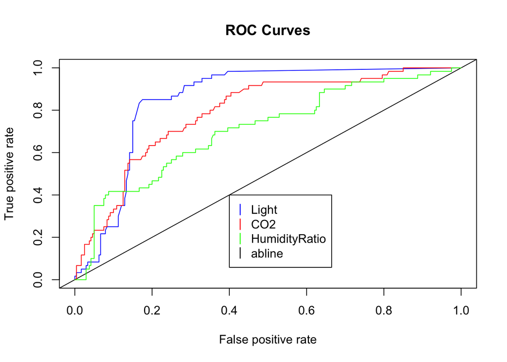

```r
perform.train.model.light = performance(pr.trained.light, measure = "tpr", x.measure = "fpr")
perform.train.model.CO2 = performance(pr.trained.CO2, measure = "tpr", x.measure = "fpr")
perform.train.model.HR = performance(pr.trained.HR, measure = "tpr", x.measure = "fpr")

plot(perform.train.model.light, col="blue", main="ROC Curves")
legend(.4,.4,
       pch=c("|","|", "|"),
       col=c("blue","red", "green", "black"),
       legend = c("Light","CO2", "HumidityRatio", "abline"))
abline(a = 0, b = 1)

plot(perform.train.model.CO2, add=TRUE, col="red")

plot(perform.train.model.HR, add=TRUE, col="green")
```

Here the abline represents when the AUROC value is 0.5 and where the model has no capacity to distinguish between the classes, i.e. is useless.

**AUROC values compared**

```r
print(paste("The AUROC value of the trained light logistic regression model is", auroc.trained.light.value))
```

```
## [1] "The AUROC value of the trained light logistic regression model is 0.850243055555556"
```

```r
print(paste("The AUROC value of the trained CO2 logistic regression model is", auroc.trained.CO2.value))
```

```
## [1] "The AUROC value of the trained CO2 logistic regression model is 0.789340277777778"
```

```r
print(paste("The AUROC value of the trained HumidityRatio logistic regression model is", auroc.trained.HR.value))
```

```
## [1] "The AUROC value of the trained HumidityRatio logistic regression model is 0.706909722222222"
```

The higher the AUROC value the better the model is at predicting classifiers (predicting 0s as 0s and 1s as 1s). An optimal value would be 1 for TPR and 0 for FPR, therefore the best value we could achieve is 1. So the light model is the model that predicts the classes best (when compared with the CO2 and HumidityRatio models) as it’s AUROC value is the highest. The HumidityRatio is the poorest model at predicting the classes as it has the lowest AUROC value. In short, more area under the curve is better.

### Question 6. Resampling methods

**(a)**  
Model B (learns parameters for a polynomial degree 4) will fit the test data better. The data was generated from a polynomial of degree 3 and we have a good amount of training data (400 x,y-pairs), so the model for polynomial of degree 4 will likely fit a small coefficient for the 4th degree. This means that in actual fact it will act like a degree 3 (which our data was built from) so model B will fit the test data better. If we had less data pairs then polynomial degree 4 might overfit the data, however as we have 400 pairs overfitting is less likely and we want to avoid using model A is it would likely underfit the data.

**(b)**

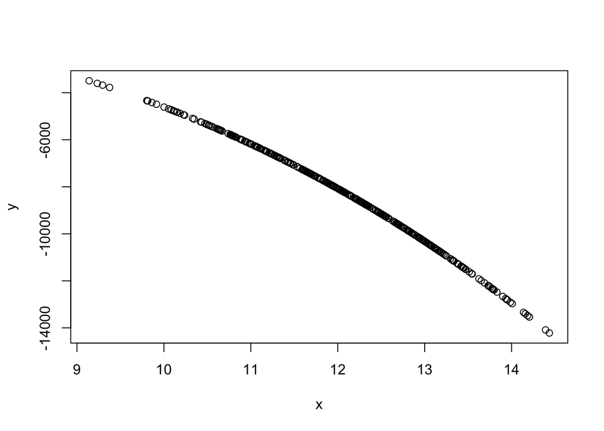

```r
set.seed(235)
x = 12 + rnorm(400)
y = 1 - x + 4*x^2 - 5*x^3 + rnorm(400)

plot(x, y)
```

**(c)**

```r
set.seed(34)
x = 12 + rnorm(400)
y = 1 - x + 4*x^2 - 5*x^3 + rnorm(400)
xy_data = data.frame(x,y)
```

**(i). Degree 2 model: LOOCV error**

```r
glm.fit1 = glm(y ~ poly(x,2), data=xy_data)
loocv1 = cv.glm(xy_data,glm.fit1)
loocv1$delta[1]
```

```
## [1] 115.8783
```

**(i). Degree 2 model: 10-fold CV error**

```r
fold10_1 = cv.glm(xy_data,glm.fit1, K=10)
fold10_1$delta[1]
```

```
## [1] 116.5439
```

**(ii). Degree 4 model: LOOCV error**

```r
glm.fit2 = glm(y ~ poly(x, 4), data=xy_data)
loocv2 = cv.glm(xy_data, glm.fit2)
loocv2$delta[1]
```

```
## [1] 0.9520189
```

**(ii). Degree 4 model: 10-fold CV error**

```r
fold10_2 = cv.glm(xy_data, glm.fit2, K=10)
fold10_2$delta[1]
```

```
## [1] 0.9471108
```

**(d)**

```r
set.seed(68)
xy_data2 = data.frame(x,y)
```

**(i). Second degree 2 model: LOOCV error**

```r
glm.fit1_second = glm(y ~ poly(x,2), data=xy_data2)
loocv1_second = cv.glm(xy_data2,glm.fit1_second)
loocv1_second$delta[1]
```

```
## [1] 115.8783
```

**(i). Second degree 2 model: 10-fold CV error**

```r
fold10_1_second = cv.glm(xy_data2,glm.fit1_second, K=10)
fold10_1_second$delta[1]
```

```
## [1] 130.9585
```

**(ii). Second degree 4 model: LOOCV error**

```r
glm.fit2_second = glm(y ~ poly(x, 4), data=xy_data2)
loocv2_second = cv.glm(xy_data2, glm.fit2_second)
loocv2_second$delta[1]
```

```
## [1] 0.9520189
```

**(ii). Second degree 4 model: 10-fold CV error**

```r
fold10_2_second = cv.glm(xy_data2, glm.fit2_second, K=10)
fold10_2_second$delta[1]
```

```
## [1] 0.9673976
```

The LOOCV error results are the same as in (c). The LOOCV errors are calculated by using the test error on every point, then taking the average of the errors - so you will get the same result every time as all possible splits are considered. However, for 10-fold CV errors the results differ from those in (c). This is because the approach involves randomly dividing the set of observations into 10 folds. This randomness means that you get a different result each time, as we can see here.

**(e)**  
The smallest LOOCV error in (c) was seen in the (ii) degree 4 model.  
The smallest 10-fold error in (c) was seen in the (ii) degree 4 model.  
This is what I expected as I anticipdated that a model learnt from a polynomial of degree 4 would be more suitable to use on data generated from a polynomial of degree 3.

**(f)**  
The preferred model in (a) is Model B, so we will view a summary using this Model:

```r
summary(glm.fit2)
```

```
##
## Call:
## glm(formula = y ~ poly(x, 4), data = xy_data)
##
## Deviance Residuals:
##     Min       1Q   Median       3Q      Max
## -3.5121  -0.6468  -0.0185   0.6312   2.8219
##
## Coefficients:
##               Estimate Std. Error    t value Pr(>|t|)
## (Intercept) -8.249e+03  4.857e-02 -1.698e+05   <2e-16 ***
## poly(x, 4)1 -4.189e+04  9.714e-01 -4.312e+04   <2e-16 ***
## poly(x, 4)2 -4.716e+03  9.714e-01 -4.855e+03   <2e-16 ***
## poly(x, 4)3 -2.034e+02  9.714e-01 -2.094e+02   <2e-16 ***
## poly(x, 4)4  2.117e+00  9.714e-01  2.179e+00   0.0299 *
## ---
## Signif. codes:  0 '***' 0.001 '**' 0.01 '*' 0.05 '.' 0.1 ' ' 1
##
## (Dispersion parameter for gaussian family taken to be 0.9436729)
##
##     Null deviance: 1.7768e+09  on 399  degrees of freedom
## Residual deviance: 3.7275e+02  on 395  degrees of freedom
## AIC: 1118.9
##
## Number of Fisher Scoring iterations: 2
```

**(g)**

```r
set.seed(34)

glm.fit.cubic = glm(y ~ poly(x, 3), data=xy_data)

loocv.cubic = cv.glm(xy_data, glm.fit.cubic)
loocv.cubic$delta[1]
```

```
## [1] 0.9650934
```

```r
fold10.cubic = cv.glm(xy_data, glm.fit.cubic, K=10)
fold10.cubic$delta[1]
```

```
## [1] 0.964096
```

```r
summary(glm.fit.cubic)
```

```
##
## Call:
## glm(formula = y ~ poly(x, 3), data = xy_data)
##
## Deviance Residuals:
##     Min       1Q   Median       3Q      Max
## -3.6206  -0.6596  -0.0093   0.6366   2.7828
##
## Coefficients:
##               Estimate Std. Error   t value Pr(>|t|)
## (Intercept) -8.249e+03  4.880e-02 -169036.5   <2e-16 ***
## poly(x, 3)1 -4.189e+04  9.760e-01  -42915.7   <2e-16 ***
## poly(x, 3)2 -4.716e+03  9.760e-01   -4832.2   <2e-16 ***
## poly(x, 3)3 -2.034e+02  9.760e-01    -208.4   <2e-16 ***
## ---
## Signif. codes:  0 '***' 0.001 '**' 0.01 '*' 0.05 '.' 0.1 ' ' 1
##
## (Dispersion parameter for gaussian family taken to be 0.9526055)
##
##     Null deviance: 1.7768e+09  on 399  degrees of freedom
## Residual deviance: 3.7723e+02  on 396  degrees of freedom
## AIC: 1121.7
##
## Number of Fisher Scoring iterations: 2
```

Now we must compare the LOOCV and 10-fold CV errors with the preferred model in (a) - Model B (Degree 4).

**Second Degree 4 results:**  
LOOCV = 0.9520189  
10-fold CV = 0.9673976

**Cubic (Degree 3) results:**  
LOOCV = 0.9650934  
10-fold CV = 0.964096

Here we can see that the LOOCV result for degree 4 is slightly lower. This is somewhat surprising as it was built off degree 3, however it shows that an increase in polynomial could be useful even if it is only very slight. It may not be worth using degree 4 as it is more computationally expensive however. We can see that the 10-fold CV error is slightly lower for the degree 3 result which was anticipated. However, again the difference is very small. The overall very close similarities between both LOOCV and 10-fold CV values for degree 3 and degree 4 supports my statement that using degree 4 (Model B) will be very similar to degree 3, and therefore is the correct model to use (out of a choice between Model A and Model B in this question).